# Coursework Report

*N* removed NAs: 2

*N* removed typo: 1

*N* removed <18: 22

*N* total clean: 125

| Group | *N* | *M*<sub>age</sub> | *M*<sub>rating</sub> |
| --- | --- | --- | --- |
| Control | 59 | 20.61 | 6.15 |
| Experim | 66 | 20.45 | 7.01 |

**Main analysis results**

*t*(123) = -6.45, *p* < .001

[interactive chart not shown]

[figure not shown]

[interactive chart not shown]

# Coursework Report

Analysing Data, Spring 2020

# Methods

## Participants

150 female participants initially took part in the experiment. However, 25 of these participants were removed from the final results due to the response given for their age being non-numeric or under 18 years old. The final data contains results from the remaining 125 participants. The youngest participant was 18 years old and the oldest was 28, giving a range of 10 years. The average age was 20.53 years old and the standard deviation was 2.1.

## Design

This experiment was designed to investigate whether women perceive men to be more attractive when their photo is presented on a red background as opposed to a white background.

The colour condition was the key independent variable in this experiment – this refers to the background colour that the photo of the men were presented on, either red or white, depending on which group each participant was allocated to.

The key dependent variable was the mean attractiveness rating. Each participant rated three different photos from 1 to 9, with 1 being ‘not at all attractive’ and 9 being ‘extremely attractive’. An average for each participant was created from these three scores.

Based on the research background, it was hypothesised that a photo of a man on a red background would receive a higher mean attractiveness rating from women than a photo of the same man on a white background. This hypothesis will be tested using an independent-measures *t*-test.

# Results

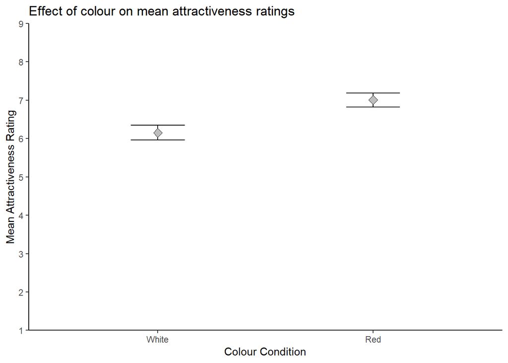

An independent-measures *t*-test was used to examine whether or not this effect was significant. This test showed that there was a significant difference in the mean attractiveness ratings of the red and white colour groups (*M*<sub>diff</sub> = -0.86, 95% CI [-1.12, -0.59], *t*(123) = -6.45, *p* < .001).

This value for *t* is -6.45, which means that the difference of -0.86 between the red and white group means is 6.45 times greater than the standard error of the difference in means. This value would be highly unlikely to occur if the true difference in means was 0 and the variance between the conditions had occurred by chance. Furthermore, given that the calculated *p*-value is less than .001, it can almost certainly be assumed that the observed effect did not occur due to chance, so the null hypothesis can be rejected and the alternative accepted.

# Discussion

This investigation found that, on average, women rate men as significantly more attractive when presented with a photo of a man on a red background as opposed to a white background.

The two mean attractiveness ratings found in this investigation are slightly higher than those in the original study by Elliot et al. (2010) – the mean for the red group is 0.22 rating points higher and the mean for the white group is 0.48 rating points higher. Overall, though, the pattern of results in this investigation is very similar to the original study, with the red group reporting significantly higher attractiveness ratings than the white group. This suggests that the positive observed effect of the colour red on attractiveness ratings is replicable.

However, other attempts to replicate the work of Elliot et al. (2010) have reported that the colour that an individual is presented alongside (e.g. red, white, black, etc.), be it as a background or as apparel, has little to no effect on attractiveness ratings. There is a decent body of work that shows this pattern (Peperkoorn et al., 2016; Hesslinger et al., 2015) that does not match the results in the original study or in this replication. This suggests that Elliot’s original study may not be as replicable as initially thought, especially when considering the small sample sizes used in that experiment (*N* = 21) and the fact that unsuccessful replications have used much larger samples (e.g. *N* = 206 in Peperkorn’s first experiment).

One of the biggest strengths of this study is that it is relatively simple to carry out as it does not require a lot of resources or time, making it easy for others to replicate. However, the photos used in the experiment are artificial stimuli and do not reflect natural human encounters, so the study lacks ecological validity. Furthermore, similar studies that have presented participants with photos of a person wearing different coloured clothes as opposed to just varying the colour of the background (Peperkoorn et al., 2016) have failed to replicate the effect seen in this study. Additionally, much of the research that supports the ‘red effect’ has been found to be underpowered (Francis, 2013), including the original study by Elliot et al. (2010).

Considering the lack of ecological validity in the design of this experiment and the lack of credible evidence to support the ‘red effect’, as well as the fact that many of the studies that have found contradictory results are more robustly designed, it seems that there is insufficient evidence to support the idea that red makes women perceive men as more attractive.

Whilst the effect of the colour red on attractiveness does not appear to be a real one, the colour red has also been found to increase the likelihood of avoidance motivation and to negatively impact performance on IQ tasks (Elliot et al., 2007; Maier et al, 2008). Given that this could have broader implications in terms of maximising productivity, perhaps in a work or school environment, this is a related area that could warrant further investigation. Maier et al. (2008) suggest that future research on priming could include colour stimuli. This colour priming research could be extended to investigate areas such as memory, which has been found to be linked to avoidance motivation (Murty et al., 2011) by briefly presenting participants with different coloured stimuli before having them carry out a short term recall task.

Ultimately, despite the success of this study to replicate the findings of Elliot et al. (2010), the bulk of the body of work that supports the ‘red effect’ is underpowered, has small sample sizes or poor ecological validity while the studies that have been found to contradict this effect are much better designed. Therefore, the evidence cannot be seen to support the original hypothesis that the colour red makes men appear more attractive to women. While further research on this area may be needed, perhaps a more interesting area of study would be the effect of colour priming on memory, based on the already established links between red and avoidance motivation and between avoidance motivation and memory.

# References

Elliot, A. J., Maier, M. A., Moller, A. C., Friedman, R., & Meinhardt, J. (2007). Color and psychological functioning: The effect of red on performance attainment. Journal of Experimental Psychology: General, 136(1), 154–168. https://doi.org/10.1037/0096-3445.136.1.154

Francis, G. (2013). Publication bias in “Red, rank, and romance in women viewing men,” by Elliot et al. (2010). Journal of Experimental Psychology: General, 142(1), 292–296. https://doi.org/10.1037/a0027923

Hesslinger, V. M., Goldbach, L., & Carbon, C.-C. (2015). Men in red: A reexamination of the red-attractiveness effect. Psychonomic Bulletin & Review, 22(4), 1142–1148. https://doi.org/10.3758/s13423-015-0866-8

Maier, M. A., Elliot, A. J., & Lichtenfeld, S. (2008). Mediation of the Negative Effect of Red on Intellectual Performance. Personality and Social Psychology Bulletin, 34(11), 1530–1540. https://doi.org/10.1177/0146167208323104

Murty, V. P., LaBar, K. S., Hamilton, D. A., & Adcock, R. A. (2011). Is all motivation good for learning? Dissociable influences of approach and avoidance motivation in declarative memory. Learning & Memory, 18(11), 712–717. https://doi.org/10.1101/lm.023549.111

Peperkoorn, L. S., Roberts, S. C., & Pollet, T. V. (2016). Revisiting the Red Effect on Attractiveness and Sexual Receptivity. Evolutionary Psychology, 14(4), 147470491667384. https://doi.org/10.1177/1474704916673841